# Mixture Modeling with JAGS

This page is about estimating a mixture models using [JAGS](http://martynplummer.wordpress.com/jags/) via [R](http://cran.us.r-project.org/).

## Two Component Mixture of Normals

The first mixture model examined considers a distribution comprised of two normal distributions. First things first, we create the data, pooling two distinct normally-distributed variables – `x1`, with a mean of 3 and standard deviation of 2; and `x2`, with a mean of 10 and standard deviation of 2. The last puts the data into the list format that JAGS requires.

```r
require(coda)
require(rjags)
require(reshape)
x1 <- rnorm(25, 3, 2)
x2 <- rnorm(75, 10, 2)
x <- c(x1,x2)
data <- list(x=x,n=length(x))
```

The JAGS code for a two-component mixture of normals is:

```
model{
  p ~ dbeta(1,1)
  mu1 ~ dnorm(10, .01)
  mu2 ~ dnorm(50, .01)
  tau <- pow(sigma, -2)
  sigma ~ dunif(0,100)
  for (i in 1:n)
      {
      z[i] ~ dbern(p)
      mu[i] <- z[i]*mu1 + (1-z[i])*mu2
      x[i] ~ dnorm(mu[i], tau)
      }
}
```

The parameters we are estimating are the means of the two component distributions, `mu1` and `mu2`. The model results also provide values `z[i]` for each observation’s probability of belonging to one of the two component distributions.

We pass initial values to JAGS in order to initialize the MCMC simulation. Note that each `x[i]` gets its own mean, but all observations share the variance, which in this case is set to equal 1.

```r
init <- list(mu=array(rnorm(1*data$n)),mu1=rnorm(1), mu2=rnorm(1),sigma=1)
```

We pass the model to JAGS using the `textConnection()` function. The text is entered into `R` as the object `modelstring`. I prefer to run the MCMC simulation using the `coda.samples()` function in the **coda** package. Another popular package for doing so is **R2Jags**.

```r
model <- jags.model(textConnection(modelstring), data=data, n.adapt=1e5)
# Run samples using coda package sampler
out <- coda.samples(model=model, init=init, variable.names=c("mu1", "mu2", "z"), n.iter=1e5, thin=20)
# Extract elements from list: our estimates of the two means
mu1 <- unlist(out[,"mu1",])
mu2 <- unlist(out[,"mu2",])
```

**Figure 1.** Density estimation for the simulated values of `mu1` and `mu2`

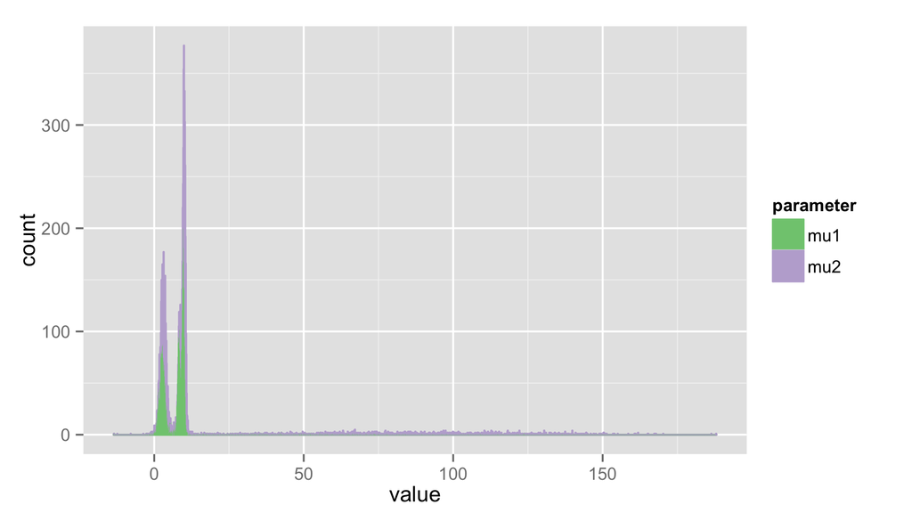

A second point of interest is related to the estimates of belonging to a particular group. In the model, the `z[i]` parameter is distributed Bernoulli. Thus, at each iteration, every observation is assigned a 0 or 1, indicating the observation’s mean is either the sampled value for `mu1` or `mu2`. Figure 2 presents this assignment variable for the `z[1]` parameter at each iteration (left panel) along with the density estimate (right panel).

**Figure 2.** Traceplot and density estimate for the `z[1]` parameter

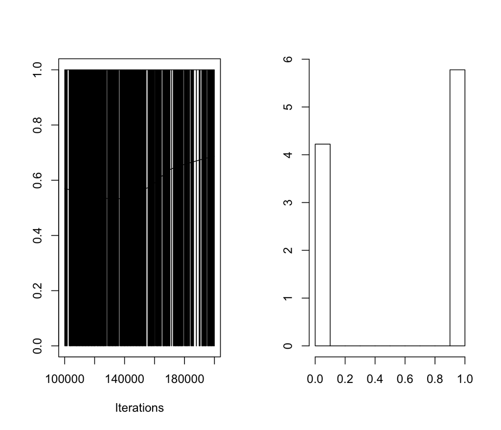

```r
plot(out[,"z[1]",])
```

**Figure 2.** Each observation’s probability of belonging to the `mu1` distribution

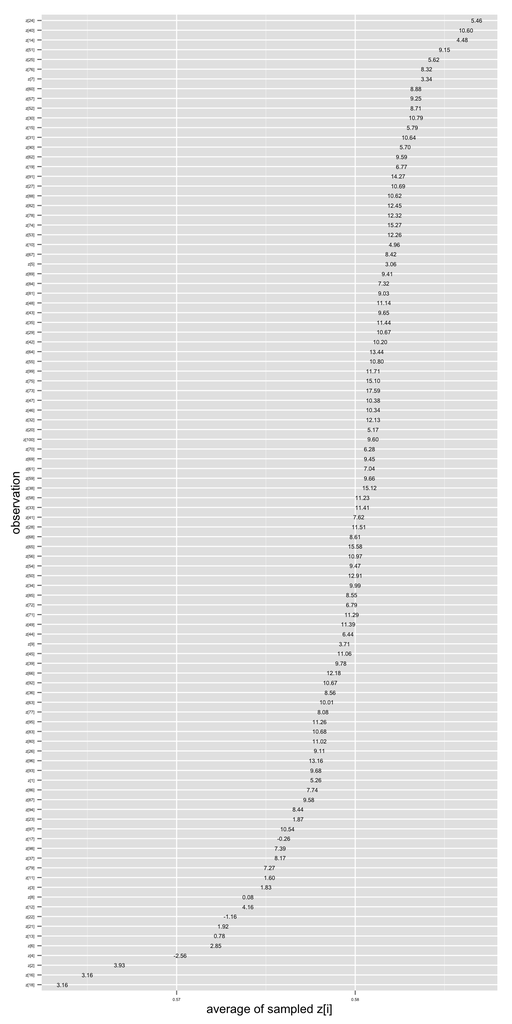

### What if there are three distributions?

In the simulation, we knew `x` was a mixture of two random normal variables. What happens when we attempt to use the two-component normal model with data that is more accurately characterized by a three-component mixture? Let’s find out by simulating some new data and re-running.

```r
x1 <- rnorm(20, 3, 2)
x2 <- rnorm(60, 10, 2)
x3 <- rnorm(20, 20, 4)

x <- c(x1,x2,x3)
data <- list(x=x,n=length(x))
```

```r
model <- jags.model(textConnection(modelstring), data=data, n.adapt=1e5)
# Run samples using coda package sampler
out <- coda.samples(model=model, init=init, variable.names=c("mu1", "mu2", "z"), n.iter=1e5, thin=20)
# Extract elements from list: our estimates of the two means
mu1 <- unlist(out[,"mu1",])
mu2 <- unlist(out[,"mu2",])
```

**Figure 3.** Density estimation for the simulated values of `mu1` and `mu2`

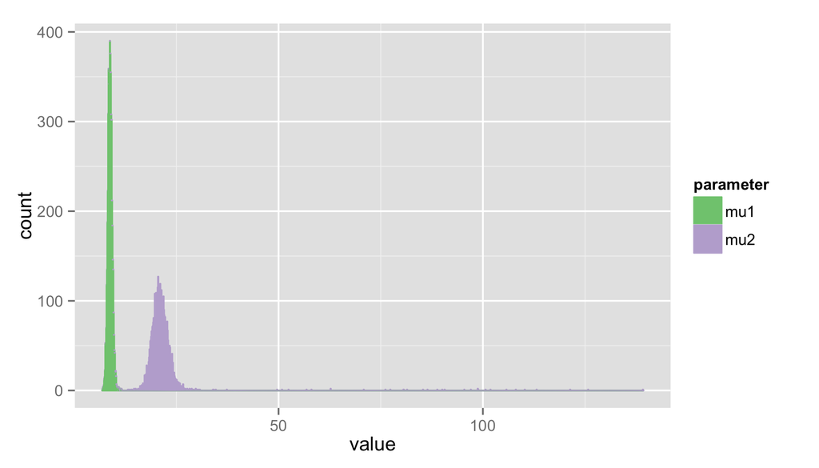

**Figure 4.** Each observation’s probability of belonging to the `mu1` distribution

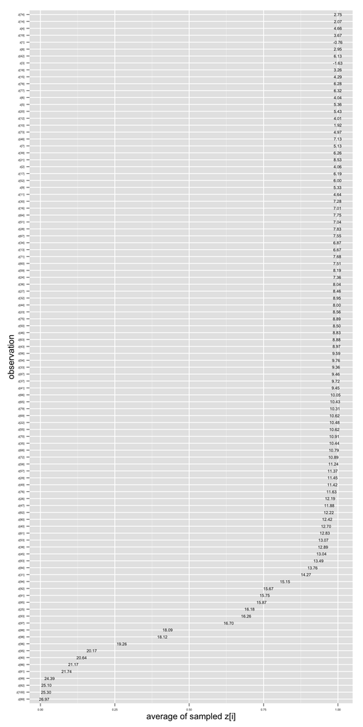